# examples_0309

The correct answer is F.

Below I've listed the parameters used to generate all patterns:

- A:
  - Turn angle = 72
  - Count max = 12

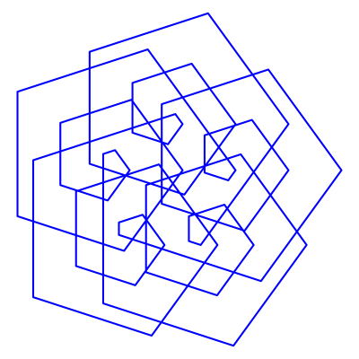

- B:
  - Turn angle = 140
  - Count max = 15

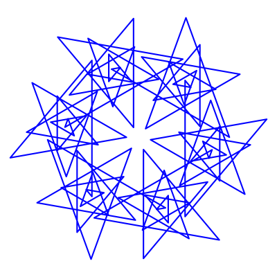

- C:
  - Turn angle = 162
  - Count max = 17

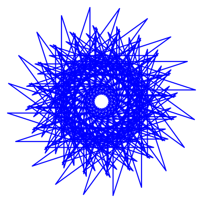

- D:
  - Turn angle = 120
  - Count max = 14

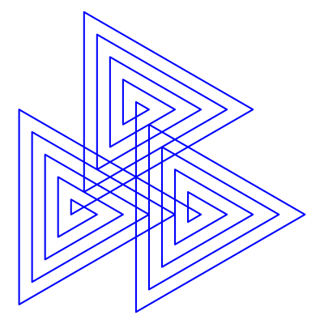

- E:
  - Turn angle = 30
  - Count max = 13

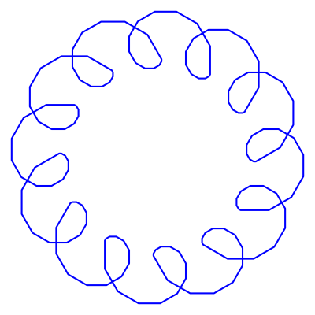

- F:
  - Turn angle = 60
  - Count max = 10

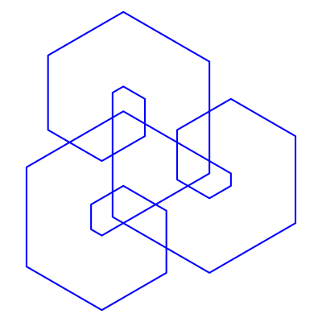

- G:
  - Turn angle = 165
  - Count max = 5

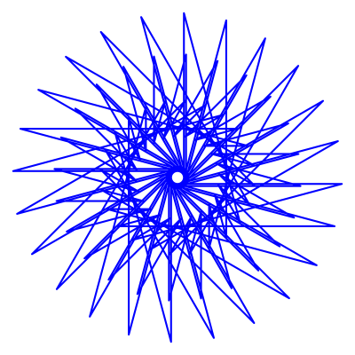

- H:
  - Turn angle = 36
  - Count max = 16

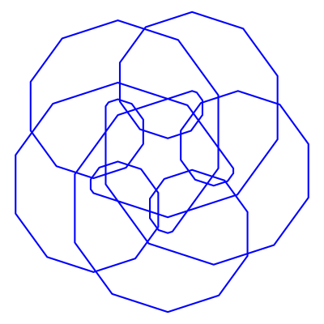

Let's say you want to make a [spirolateral](https://en.wikipedia.org/wiki/Spirolateral).

If the turn angle is $\theta=30^{\circ}$ and the maximum segment length is $n=20$, then which spirolateral is created?

You can use this tool:

https://artockthedino.github.io/pbl/spirolateral/spirolateral_generator.html

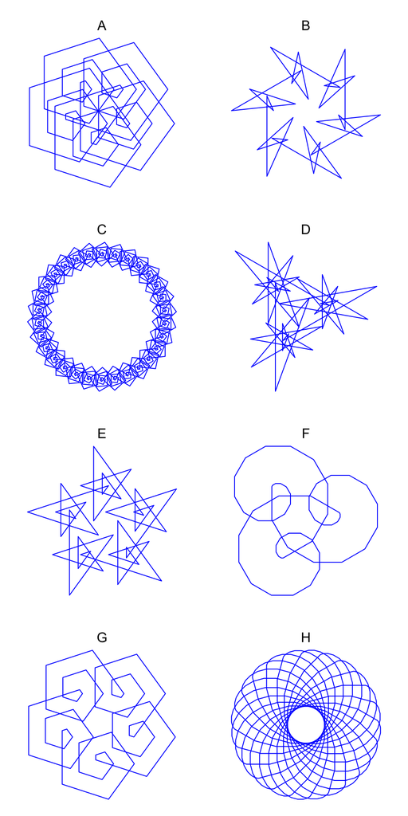

ABCDEFGH

The correct answer is F.

Below I've listed the parameters used to generate all patterns:

- A:
  - Turn angle = 72
  - Count max = 13

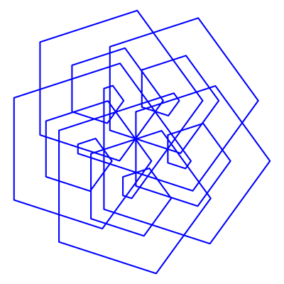

- B:
  - Turn angle = 156
  - Count max = 5

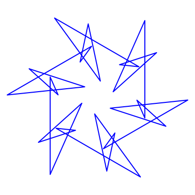

- C:
  - Turn angle = 84
  - Count max = 17

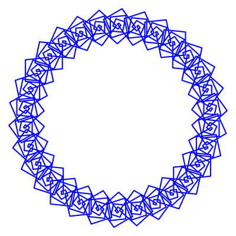

- D:
  - Turn angle = 160
  - Count max = 12

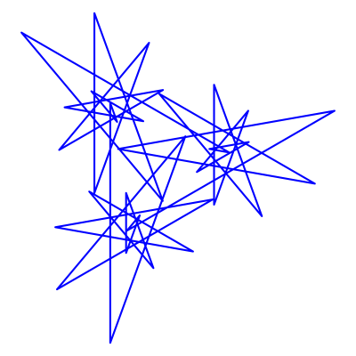

- E:
  - Turn angle = 144
  - Count max = 8

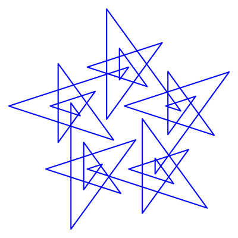

- F:
  - Turn angle = 30
  - Count max = 20

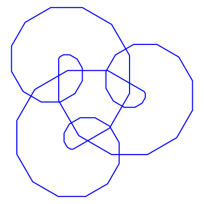

- G:
  - Turn angle = 72
  - Count max = 11

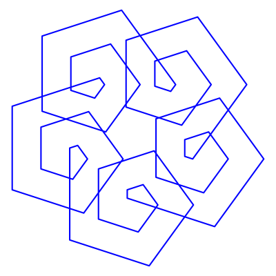

- H:
  - Turn angle = 15
  - Count max = 17

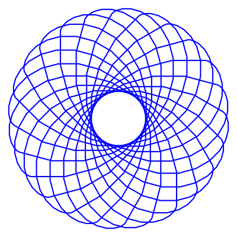

Let's say you want to make a [spirolateral](https://en.wikipedia.org/wiki/Spirolateral).

If the turn angle is $\theta=63^{\circ}$ and the maximum segment length is $n=5$, then which spirolateral is created?

You can use this tool:

https://artockthedino.github.io/pbl/spirolateral/spirolateral_generator.html

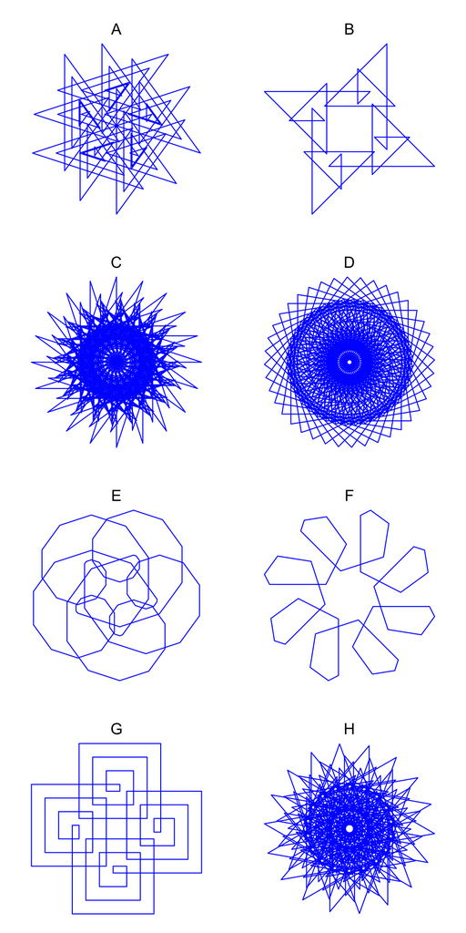

ABCDEFGH

The correct answer is F.